# Day 4: Logistic Regression

```r
# Load packages
library(tidyverse)
library(palmerpenguins)
```

When building models, we can only learn from non-missing values, let’s ignore those for now:

```r
# Save a version of the penguins dataset, removing any missing values
penguins_clean <- as.data.frame(penguins) |>
  # Filter any missing values
  na.omit()
```

So far, we have discussed tests and models with a numeric response (testing about the mean/predicting the mean). What if our response was categorical?

## 1. Chi-squared tests

We will start by discussing Chi-squared tests.

### a. Chi-squared Goodness of Fit

> Research Question: Is there a different amount of penguins for each species?
1. Hypotheses:
- H0: All species are equally represented (1/3 each).
- Ha: The proportions of penguin species are not all equal.
2. Find descriptive statistics:

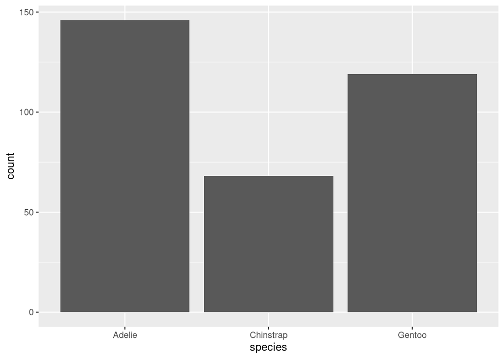

```r
penguins_clean |>
  # Make a plot
  ggplot() +
  # Use geom_bar and define mapping aesthetics
  geom_bar(aes(x = species))
```

```r
# Report frequencies with table
table(penguins_clean$species)
```

```
##
##    Adelie Chinstrap    Gentoo
##       146        68       119
```

3. Compare the estimate to the claim:

```r
# Conduct the test
chisq.test(table(penguins_clean$species), p=c(1/3,1/3,1/3))
```

```
##
##  Chi-squared test for given probabilities
##
## data:  table(penguins_clean$species)
## X-squared = 28.27, df = 2, p-value = 7.264e-07
```

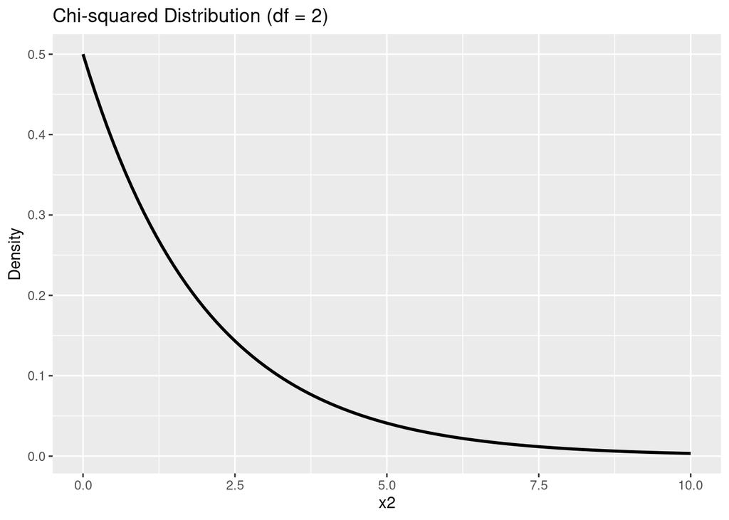

```r
# Check the distribution with df = 1
ggplot(data.frame(x2 = c(0, 10)), aes(x2)) +
  stat_function(fun = dchisq, args = list(df = 2),
                geom = "line", linewidth = 1) +
  labs(title = "Chi-squared Distribution (df = 2)",
       x = "x2", y = "Density")
```

```r
# Check the p-value calculation
pchisq(q = 28.27, df = 2, lower.tail = FALSE)
```

```
## [1] 7.265199e-07
```

What do you think about the assumptions?

- Random sample
- Independent observations
- Sample size

### b. Chi-squared Test of Independence

> Research Question: Is there a difference in sex distribution across the different species?
1. Hypotheses:
- H0: Species and sex are independent.
- Ha: Species and sex are not independent (dependent).
2. Find descriptive statistics:

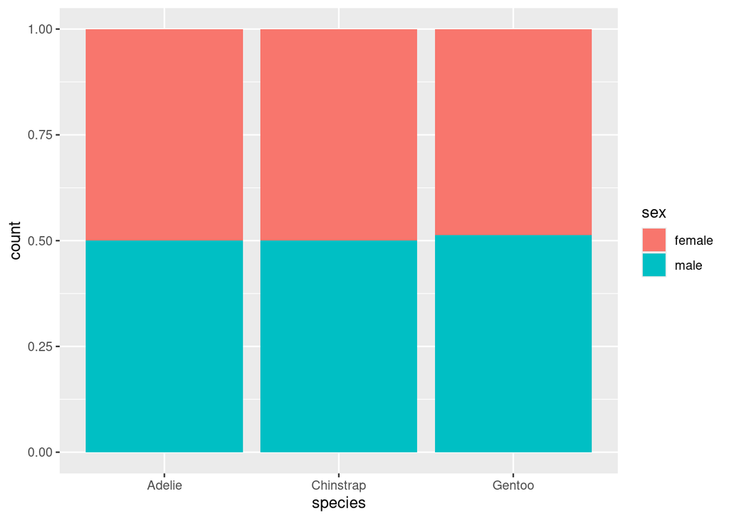

```r
penguins_clean |>
  # Make a plot
  ggplot() +
  # Use geom_bar and define mapping aesthetics with fill
  geom_bar(aes(x = species, fill = sex), position = "fill")
```

```r
# Report frequencies with table
table(penguins_clean$sex, penguins_clean$species)
```

```
##
##          Adelie Chinstrap Gentoo
##   female     73        34     58
##   male       73        34     61
```

3. Compare the estimate to the claim:

```r
# Conduct the test
chisq.test(table(penguins_clean$species, penguins_clean$sex))
```

```
##
##  Pearson's Chi-squared test
##
## data:  table(penguins_clean$species, penguins_clean$sex)
## X-squared = 0.048607, df = 2, p-value = 0.976
```

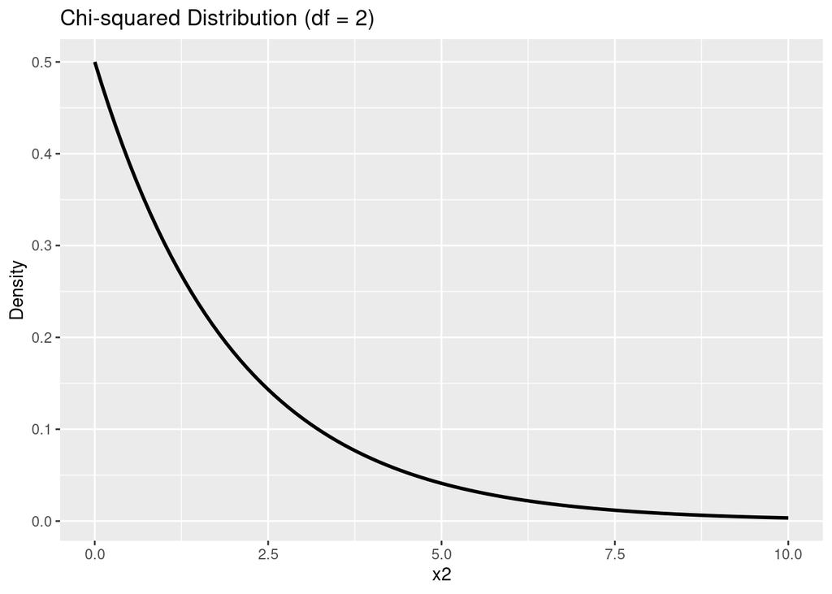

```r
# Check the distribution with df = 1
ggplot(data.frame(x2 = c(0, 10)), aes(x2)) +
  stat_function(fun = dchisq, args = list(df = 2),
                geom = "line", linewidth = 1) +
  labs(title = "Chi-squared Distribution (df = 2)",
       x = "x2", y = "Density")
```

```r
# Check the p-value calculation
pchisq(q = 0.048607, df = 2, lower.tail = FALSE)
```

```
## [1] 0.9759895
```

4. Interpret in context: The proportions of male/female penguins is not significant different across species (X-squared = 0.05, df = 2, p-value = 0.976).

What do you think about the assumptions?

- Random sample
- Independent observations
- Sample size

What if instead of testing for the association, we would like to predict a categorical outcome?

## 2. Introduction to classification

> Research Question: Can the body mass predict if a penguin is male?

Take a look at the relationship between these two variables again:

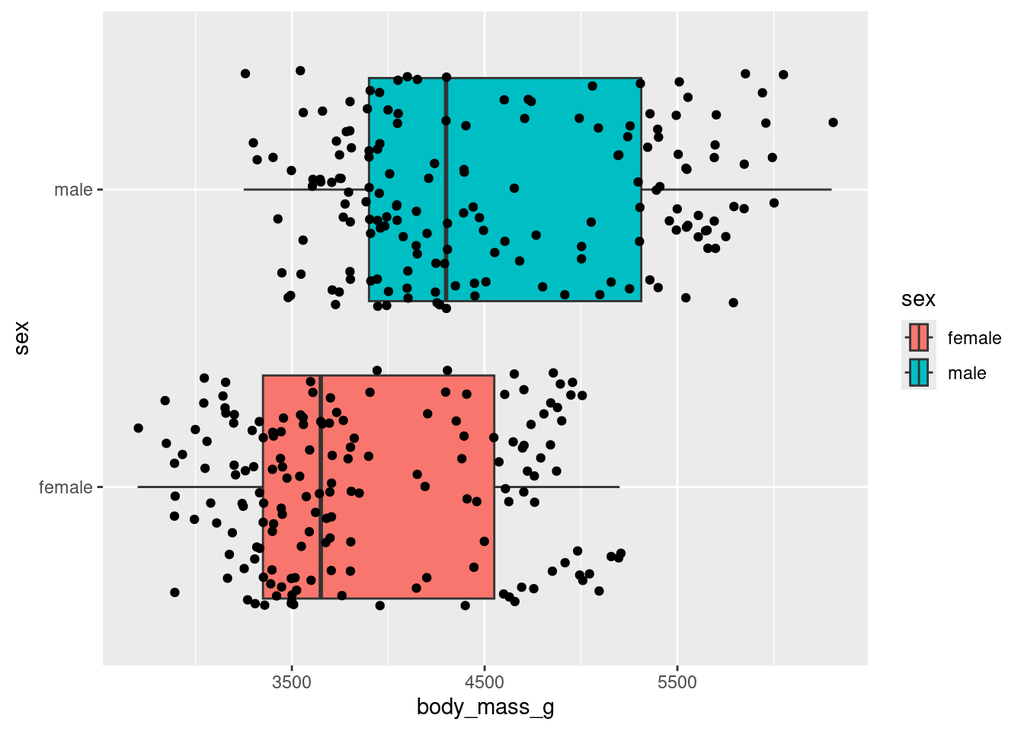

```r
penguins_clean |>
  # Make a plot
  ggplot() +
  # Use geom_boxplot and define mapping aesthetics: x = predictor, y = outcome
  geom_boxplot(aes(x = body_mass_g, y = sex, fill = sex)) +
  # Add the data
  geom_jitter(aes(x = body_mass_g, y = sex))
```

Penguins with a large body mass seems more likely to be male.

### a. Random classification

Let’s first predict the outcome randomly. For example, a penguin with any value of `body_mass_g` could be either classified as male or female.

```r
# Create a new object
penguins_pred <- penguins_clean |>
  # Only keep variables of interest
  select(body_mass_g, sex) |>
  # Create a predicted variable: using the `sample()` function sample
  mutate(predicted = sample(x = c("female","male"), # values to sample from
                            size = nrow(penguins_clean), # how many values to sample
                            replace = TRUE)) # can use each value more than once

# Take a look at the predicted variable
head(penguins_pred)
```

```
##   body_mass_g    sex predicted
## 1        3750   male    female
## 2        3800 female      male
## 3        3250 female      male
## 5        3450 female      male
## 6        3650   male    female
## 7        3625 female    female
```

Were our predicted values correct?

```r
# How do the predicted values compare to the outcome values?
table(outcome = penguins_pred$sex, predicted = penguins_pred$predicted)
```

```
##         predicted
## outcome  female male
##   female     77   88
##   male       85   83
```

Sometimes the predicted values were correct, sometimes were not correct. We can compute the accuracy of our predicted values:

```r
# Accuracy
mean(penguins_pred$sex == penguins_pred$predicted)
```

```
## [1] 0.4804805
```

Do we all get the same accuracy? Why/Why not? Why does it make sense to get about 50% accuracy?

### b. Classification based on 1 variable

As observed earlier, we think that higher values of `body_mass_g` seem to indicate than the penguin is more likely to be male:

```r
# Update our new object
penguins_pred <- penguins_clean |>
  # Only keep variables of interest
  select(body_mass_g, sex) |>
  # Create another predicted variable based on clump_thickness > 9
  mutate(predicted = ifelse(body_mass_g > 5000,
                            "male", "female"))

# Take a look at the new predicted variable
head(penguins_pred)
```

```
##   body_mass_g    sex predicted
## 1        3750   male    female
## 2        3800 female    female
## 3        3250 female    female
## 5        3450 female    female
## 6        3650   male    female
## 7        3625 female    female
```

Were our predicted values correct?

```r
# How do the predicted values compare to the outcome values?
table(outcome = penguins_pred$sex, predicted = penguins_pred$predicted)
```

```
##         predicted
## outcome  female male
##   female    160    5
##   male      112   56
```

Very few females were predicted as males (called false positive) but only a few males were predicted correctly as males (true positive). Did the accuracy improve though?

```r
# Accuracy
mean(penguins_pred$sex == penguins_pred$predicted)
```

```
## [1] 0.6486486
```

In addition to accuracy, we should consider these two metrics for evaluating our classification:

- *true positive* rate (TPR): number of truly predicted positive cases over the number of positive cases.
- *false positive* rate (FPR): number of truly negative cases that were falsely predicted to be positive over the number of negative cases.

```r
# Confusion matrix: compare the true outcomes to predicted values
table(outcome = penguins_pred$sex, predicted = penguins_pred$predicted) |>
  # Add total cases for rows and columns
  addmargins()
```

```
##         predicted
## outcome  female male Sum
##   female    160    5 165
##   male      112   56 168
##   Sum       272   61 333
```

#### **Try it! Based on the table and definitions above, what is the value of TPR? What is the value of FPR? What shall we do to increase the value of TPR? How would it affect the value of FPR?**

```r
# TPR
56/168
```

```
## [1] 0.3333333
```

```r
# FPR
5/165
```

```
## [1] 0.03030303
```

TPR ≈ 0.333 meaning that only ~33% of males were correctly classified.

FPR ≈ 0.03 meaning that very few females were incorrectly classified as males.

We could increase TPR by lowering the threshold, but that would increase FPR as well.

### d. ROC/AUC

We could try other cutoff values for `body_mass_g` to determine if a penguin is male or not. The trade-off between TPR and FPR can be represented by the Receiver Operating Characteristics (ROC) curve which can help for choosing a cutoff value that maximizes TPR while minimizes FPR.

We will use the `plotROC` package. Install it if you are using it for the first time:

```r
# Install new packages (only needed once!)
install.packages("plotROC")
```

Then load the library:

```r
# Load packages
library(plotROC)
```

A ROC curve usually represents FPR on the x-axis and the TPR on the y-axis:

```
## Warning in verify_d(data$d): D not labeled 0/1, assuming female = 0 and male =
## 1!
```

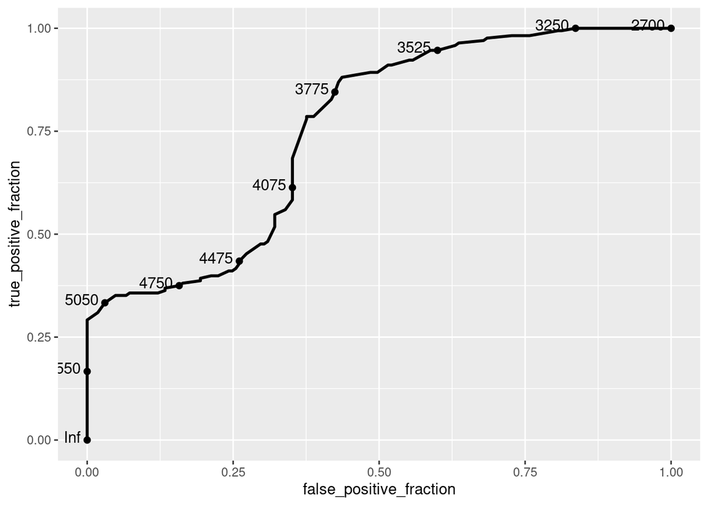

```r
penguins_clean |>
  # Make a plot
  ggplot() +
  # d is the response, m is the predictor
  geom_roc(aes(d = sex, m = body_mass_g), n.cuts = 10)
```

*Note: R usually expects the outcome to be coded as 0 and 1, representing a negative and positive outcome, respectively. The warning lets you know how R encoded the outcome.*

The area under the curve (AUC) quantifies how well our classification is predicting the outcome.

```r
# Calculate the area under the curve with function calc_auc()
calc_auc(penguins_clean |>
  # Make a plot
  ggplot() +
  # d is the response, m is the predictor
  geom_roc(aes(d = sex, m = body_mass_g), n.cuts = 10))$AUC
```

```
## Warning in verify_d(data$d): D not labeled 0/1, assuming female = 0 and male =
## 1!
```

```
## [1] 0.7520022
```

Let’s investigate what it means. If we randomly select 2 penguins, one is female and the other is male, we will compare their body mass:

- if the body mass was higher for the male penguin, we assign a probability of 1 (that agrees with our model),
- if the body mass was the same for the two penguins, we assign a probability of 0.5,
- if the body mass was lower for the male penguin, we assign a probability of 0 (that does not agree with our model).

Then we replicate that process 1,000 times.

```r
# Replicate the process 1000 times
probs <- replicate(1000,{

  # Sample 1 male penguin
  rand_positive <- penguins_clean |>
    filter(sex == "male") |>
    select(body_mass_g) |>
    sample_n(size = 1) |> pull()

  # Sample 1 female penguin
  rand_negative <- penguins_clean |>
    filter(sex == "female") |>
    select(body_mass_g) |>
    sample_n(size = 1) |> pull()

  # Assign a probability value according to our model
  case_when(rand_positive > rand_negative ~ 1,
            rand_positive == rand_negative ~ .5,
            rand_positive < rand_negative ~ 0)
})

# AUC
mean(probs)
```

```
## [1] 0.769
```

You can interpret the AUC as the fact that a randomly selected heavy penguin has a higher predicted probability to be male than a randomly selected female penguin. On average, about 76% of the time, heavy penguins will have higher probabilities of being male compared to female penguins.

In a nutshell: the higher the AUC, the better the model is!

## 3. Logistic Regression

Let’s introduce another dataset that contains information about 155 patients with information of their diabetic status and other biological characteristics. Here is a list and description of each variable in the dataset:

| Variable | Description |
| --- | --- |
| Subject | ID variable |
| Age | Age of participant (young adult, adult, older adult) |
| Gender | Gender (1 = Male, 2 = Female) |
| Diabetic | Diabetic status (0 = No, 1 = Yes) |
| Edema | Presence of edema (0 = No, 1 = Yes) |
| Cholesterol | Cholesterol level (mg/dL) |
| Glucose | Glucose level (mmol/L) |
| BP | Diastolic blood pressure (mmHg) |
| BMI | Body mass index (kg/$m^2$) |
| Platelet | Platelet counts (1,000/mL) |

```r
# Upload the data from GitHub
diabetes <- read_csv("https://raw.githubusercontent.com/laylaguyot/datasets/main//diabetes.csv")
# View first 6 rows
head(diabetes)
```

```
## # A tibble: 6 × 10
##   Subject Age     Gender Diabetic Edema Cholesterol Glucose    BP   BMI Platelet
##     <dbl> <chr>    <dbl>    <dbl> <dbl>       <dbl>   <dbl> <dbl> <dbl>    <dbl>
## 1       1 adult        1        1     0         302     148    72  33.6      221
## 2       2 older …      2        0     1         176      85    66  26.6      151
## 3       3 adult        1        0     1         244      89    66  28.1      183
## 4       4 young …      1        1     0         279      78    50  31        136
## 5       5 adult        2        1     0         322     197    70  30.5      204
## 6       6 adult        2        1     0         280     166    72  25.8      373
```

> Research Question: Does BMI predict diabetic status?

Before we start investigating the data with a model, explore the data with a visualization and statistics:

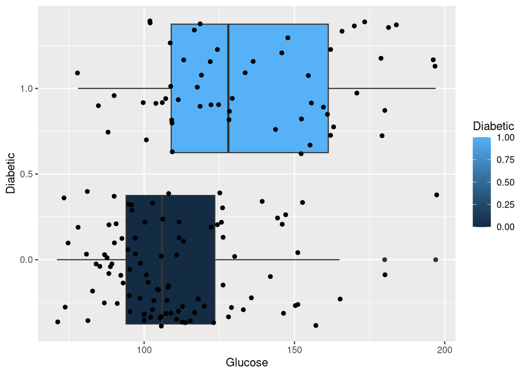

```r
# Make a plot
diabetes |>
  # Make a plot
  ggplot() +
  # Use geom_boxplot and define mapping aesthetics: x = predictor, y = outcome
  geom_boxplot(aes(x = Glucose,
                   y = Diabetic, fill = Diabetic, group = Diabetic)) +
  # Add the data
  geom_jitter(aes(x = Glucose, y = Diabetic))
```

```r
# Report statistics
```

[output not shown]

*Note: being diabetic will be considered a “positive” case in this context since our response variable takes the value 1 for diabetic patients.*

### a. Visualizing the model

We can use the `glm` method to visualize a logistic model:

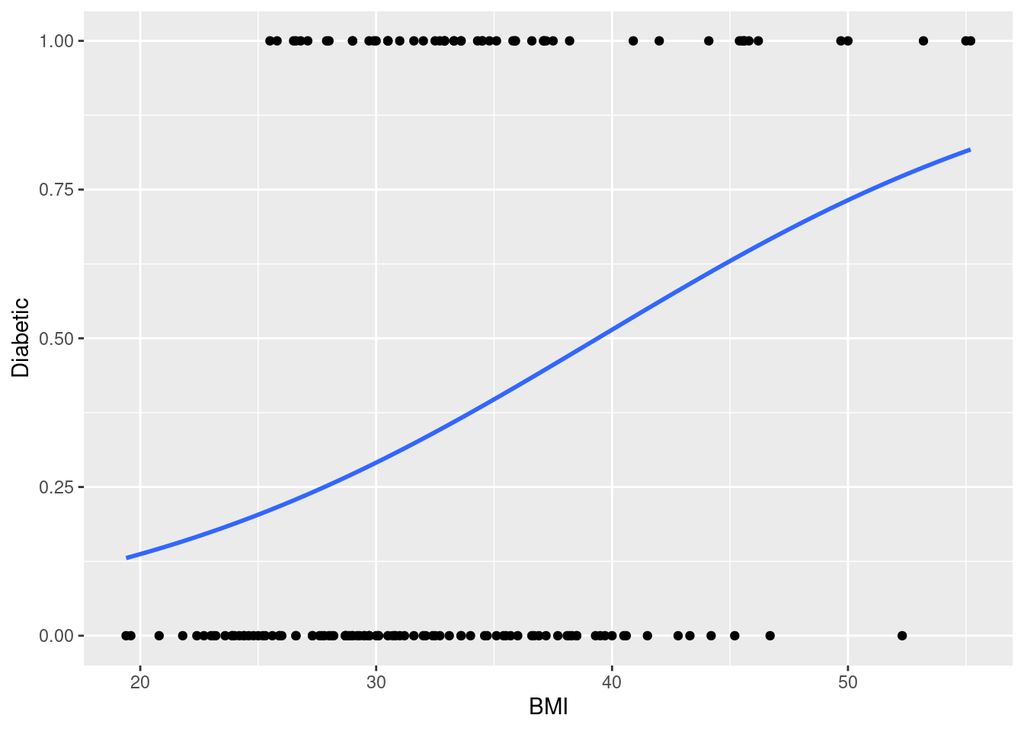

```r
diabetes |>
  # Make a plot
  ggplot() +
  # Scatterplot (not the best for this data but convenient here)
  geom_point(aes(x = BMI, y = Diabetic)) +
  # Visualize regression curve
  geom_smooth(aes(x = BMI, y = Diabetic),
              method = "glm", method.args = list(family = "binomial"), se = FALSE)
```

How did R choose a logistic curve to fit this data?

### b. Fitting a model

R fits the logistic curve using maximum likelihood estimation. The resulting curve models the probability of the outcome as a function of the predictor. We can find the expression of the logistic regression model with the `glm(outcome ~ predictor, family = "binomial")` function (`glm` stands for generalized linear models):

```r
# Fit the model
fit_model <- glm(Diabetic ~ BMI, data = diabetes, family = "binomial")

# Take a look at the model summary
summary(fit_model)
```

```
##
## Call:
## glm(formula = Diabetic ~ BMI, family = "binomial", data = diabetes)
##
## Coefficients:
##             Estimate Std. Error z value Pr(>|z|)
## (Intercept) -3.73531    0.87984  -4.245 2.18e-05 ***
## BMI          0.09483    0.02563   3.700 0.000216 ***
## ---
## Signif. codes:  0 '***' 0.001 '**' 0.01 '*' 0.05 '.' 0.1 ' ' 1
##
## (Dispersion parameter for binomial family taken to be 1)
##
##     Null deviance: 202.79  on 154  degrees of freedom
## Residual deviance: 187.16  on 153  degrees of freedom
## AIC: 191.16
##
## Number of Fisher Scoring iterations: 4
```

We can write the expression of our linear model to predict log-odds with the estimates:

$log(\widehat{odds}) = -3.73531+0.09483*BMI$

This is called the **logit form** of our model. We can write the **odds form** of the model as follows:

$\widehat{odds}=e^{-3.73531}e^{0.09483*BMI}$

We use that model form to interpret the estimates provided in the output of our model, because we interpret the odds rather than the log(odds). We exponentiate the coefficients:

```r
# Exponentiate the coefficients
exp(fit_model$coefficients)
```

```
## (Intercept)         BMI
##  0.02386586  1.09946654
```

The “slope” of BMI represents the odds ratio between 2 different values of our explanatory variable.

If the explanatory variable is numeric, the “slope” represents the odds ratio for two values of our explanatory variable spaced one unit apart:

$\beta_1 = \frac{odds for X + 1}{odds for X}$

In our example, the odds for having diabetes are 1.099 times more for each increase of BMI by 1 kg/$m^2$.

If the explanatory variable is categorical, the “slope” represents the odds ratio for two categories of our explanatory variable:

$\beta_1 = \frac{odds for X = 1}{odds for X = 0}$

### c. Predicting values

We can convert odds to probabilities and write the **probability form** of our model as follows:

$\hat{p}=\frac{e^{-3.73531+0.09483*BMI}}{{1+e^{-3.73531+0.09483*BMI}}}$

We usually use that model form to make predictions.

```r
# Calculate the corresponding prediction
predict(fit_model, newdata = data.frame(BMI = 25), type = "response")
```

```
##         1
## 0.2034809
```

A patient with a BMI of 25 kg/$m^2$ has a predicted probability of 20.3% to be diabetic.

*Note: we use the argument `type = "response"` to refer to the probabilities otherwise default would give us the logit values.*

We can use the equation above to predict values or use an R function:

```r
diabetes |>
  # Calculate predicted probabilities
  mutate(predicted = predict(fit_model, type = "response")) |>
  # Just show the variables of interest
  select(BMI, Diabetic, predicted)
```

```
## # A tibble: 155 × 3
##      BMI Diabetic predicted
##    <dbl>    <dbl>     <dbl>
##  1  33.6        1     0.366
##  2  26.6        0     0.229
##  3  28.1        0     0.255
##  4  31          1     0.311
##  5  30.5        1     0.301
##  6  25.8        1     0.216
##  7  45.8        1     0.647
##  8  43.3        0     0.592
##  9  39.3        0     0.498
## 10  29          1     0.272
## # ℹ 145 more rows
```

Which cutoff value should we consider to predict if someone is diabetic or not?

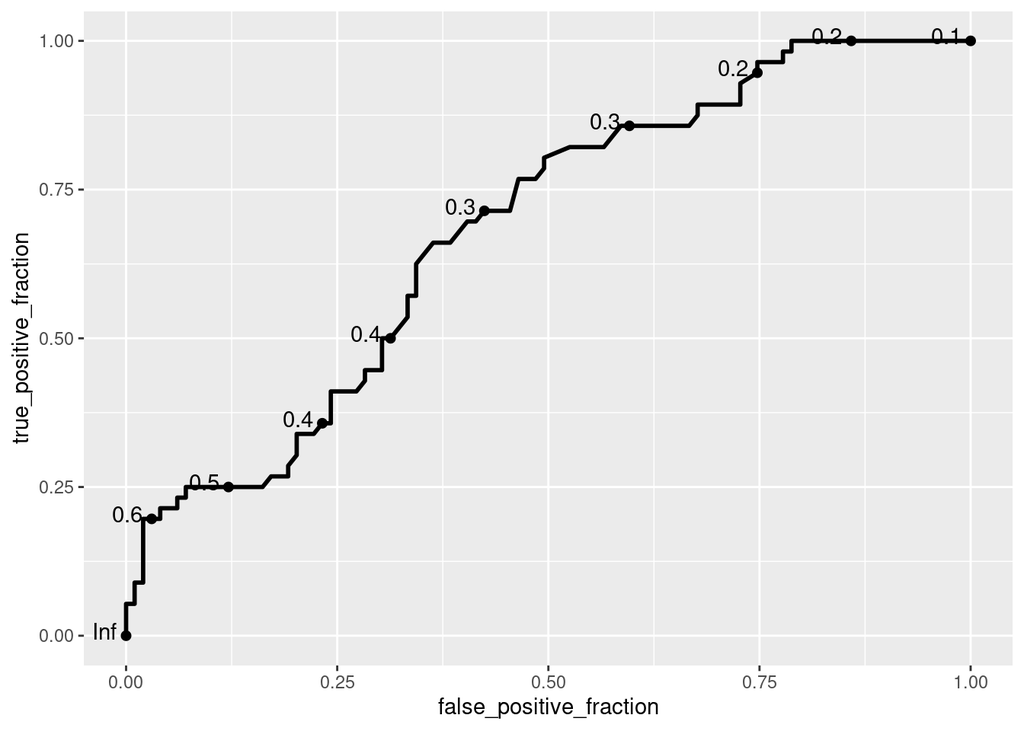

```r
# ROC curve
diabetes |>
  # Make a plot
  ggplot() +
  # d is the response, m is the predictor
  geom_roc(aes(d = Diabetic, m = predict(fit_model, type = "response")), n.cuts = 10)
```

### d. Error in predicted values

Sometimes our predicted values are correct, sometimes they’re not! Recall the concepts of True Positive (correct predicted values) and False Positive (incorrect predicted values).

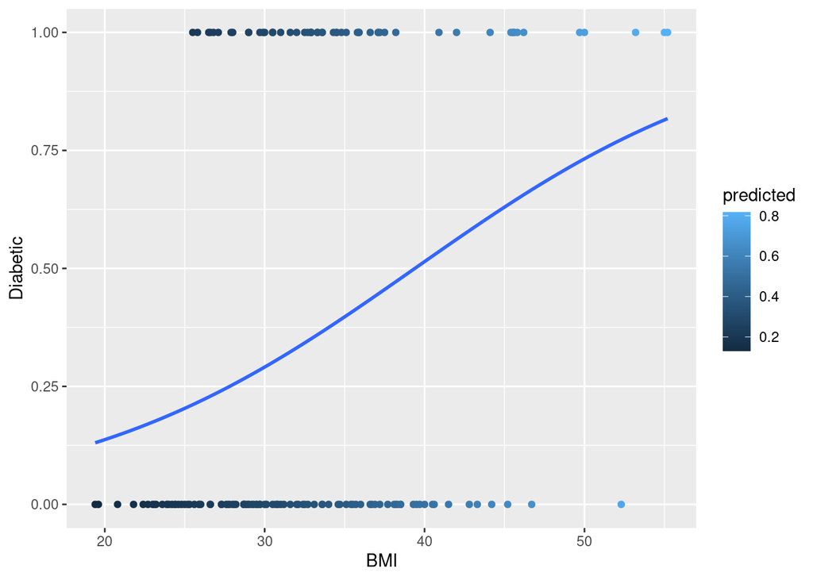

```r
diabetes |>
  # Calculate predicted probabilities
  mutate(predicted = predict(fit_model, type = "response")) |>
  # Make a plot
  ggplot() +
  # Scatterplot (colored by the predicted probabilities)
  geom_point(aes(x = BMI, y = Diabetic, color = predicted)) +
  # Visualize regression curve
  geom_smooth(aes(x = BMI, y = Diabetic),
              method = "glm", method.args = list(family = "binomial"), se = FALSE)
```

Where are we more likely to have true positive cases? false positive cases?

### e. Assessing our model

We can assess the fit of our model with the area under the ROC curve:

```r
# Calculate the area under the curve with function calc_auc()
calc_auc(diabetes |>
  # Make a plot
  ggplot() +
  # d is the response, m is the predictor
  geom_roc(aes(d = Diabetic, m = predict(fit_model, type = "response")), n.cuts = 10))$AUC
```

```
## [1] 0.6815476
```

Hmm not so great…

We can also report the deviance (similar to the idea of $SS\_error$ for linear regression) or with the Akaike’s Information Criterion (AIC, which takes into account sample size and number of predictors included in the model, somewhat similar to adjusted $R^{2}$ for linear regression).

```r
# Deviance
fit_model$deviance
```

```
## [1] 187.158
```

```r
# AIC
fit_model$aic
```

```
## [1] 191.158
```

The model is a better fit if the deviance and AIC are minimal. We mainly use these criteria to compare different logistic regression models.

There is another analogue $R^{2}$ for linear regression for logistic regression called pseudo-$R^{2}$. It does not have a direct interpretation as “percent variance explained” but can be used for comparing models. One common version is McFadden’s pseudo-$R^{2}$:

```r
# Calculate McFadden's pseudo R-squared
1 - (fit_model$deviance / fit_model$null.deviance)
```

```
## [1] 0.07707882
```

Values between 0.2 and 0.4 are considered good for logistic regression, so… not so great.

### f. Inference

The notation $\beta_1$ refers to the slope for the population. Then the hypotheses to test about the significance of the slope are:

1. Hypotheses:
- H0: The population slope of BMI on diabetic status is 0.
- Ha: The population slope of BMI on diabetic status is not 0.
2. To find descriptive statistics and 3. Compare the estimate to the claim, we use the model summary:

```r
# Take another look at the model summary
summary(fit_model)
```

```
##
## Call:
## glm(formula = Diabetic ~ BMI, family = "binomial", data = diabetes)
##
## Coefficients:
##             Estimate Std. Error z value Pr(>|z|)
## (Intercept) -3.73531    0.87984  -4.245 2.18e-05 ***
## BMI          0.09483    0.02563   3.700 0.000216 ***
## ---
## Signif. codes:  0 '***' 0.001 '**' 0.01 '*' 0.05 '.' 0.1 ' ' 1
##
## (Dispersion parameter for binomial family taken to be 1)
##
##     Null deviance: 202.79  on 154  degrees of freedom
## Residual deviance: 187.16  on 153  degrees of freedom
## AIC: 191.16
##
## Number of Fisher Scoring iterations: 4
```

This data provides evidence that BMI is a significant predictor of the diabetic status (z = 3.7, p = 0.000216).

If the slope is significantly different from 0, we can report a confidence interval (for the odds):

```r
# Calculates 95% confidence intervals for the coefficients
exp(confint(fit_model, level = 0.95))
```

```
##                   2.5 %    97.5 %
## (Intercept) 0.003891565 0.1248418
## BMI         1.047655478 1.1591207
```

For every additional 1-kg/$m^2$ increase in BMI, the odds for having diabetes are between 1.05 to 1.16 (vs not diabetic), at the 95% confidence level.

#### **Try it! Choose a different numeric variable (other than BMI) to predict if a patient is diabetic:**

- **Is this new predictor significantly associated with diabetic status?**
- **How does this model compare to the one using BMI: is it better at predicting diabetic status?**

```r
# Fit the model
fit_model <- glm(Diabetic ~ Glucose, data = diabetes, family = "binomial")

# Take a look at the model summary
summary(fit_model)
```

```
##
## Call:
## glm(formula = Diabetic ~ Glucose, family = "binomial", data = diabetes)
##
## Coefficients:
##              Estimate Std. Error z value Pr(>|z|)
## (Intercept) -4.529503   0.859942  -5.267 1.39e-07 ***
## Glucose      0.032648   0.006876   4.748 2.05e-06 ***
## ---
## Signif. codes:  0 '***' 0.001 '**' 0.01 '*' 0.05 '.' 0.1 ' ' 1
##
## (Dispersion parameter for binomial family taken to be 1)
##
##     Null deviance: 202.79  on 154  degrees of freedom
## Residual deviance: 175.17  on 153  degrees of freedom
## AIC: 179.17
##
## Number of Fisher Scoring iterations: 4
```

```r
# Interpret slope
exp(fit_model$coefficients)
```

```
## (Intercept)     Glucose
##  0.01078604  1.03318657
```

Glucose level is a significant predictor of diabetic status and this model is a little better at predicting the probability of being diabetic since the deviance has decreased.

Now, let’s also try a predictor that is categorical:

```r
# Fit the model
fit_model <- glm(Diabetic ~ Age, data = diabetes, family = "binomial")

# Take a look at the model summary
summary(fit_model)
```

```
##
## Call:
## glm(formula = Diabetic ~ Age, family = "binomial", data = diabetes)
##
## Coefficients:
##                Estimate Std. Error z value Pr(>|z|)
## (Intercept)     -0.3469     0.2040  -1.700   0.0891 .
## Ageolder adult  -0.7030     0.4842  -1.452   0.1466
## Ageyoung adult  -0.6182     0.4629  -1.336   0.1817
## ---
## Signif. codes:  0 '***' 0.001 '**' 0.01 '*' 0.05 '.' 0.1 ' ' 1
##
## (Dispersion parameter for binomial family taken to be 1)
##
##     Null deviance: 202.79  on 154  degrees of freedom
## Residual deviance: 199.37  on 152  degrees of freedom
## AIC: 205.37
##
## Number of Fisher Scoring iterations: 4
```

How to interpret the slopes in this output?

```r
# Interpret slope (multiply by -1 to interpret odds greater than 1)
exp(fit_model$coefficients*-1)
```

```
##    (Intercept) Ageolder adult Ageyoung adult
##       1.414634       2.019704       1.855603
```

## 4. Multiple Logistic Regression

> Research Question: Is there an interaction between BMI and Age on diabetic status?

Now we should fit a logistic regression model with diabetic status as the response and both BMI and Age as the explanatory variables. In addition, we can consider an interaction term between the two predictors:

```r
# Remember to mean center our numeric predictors involved in the interaction
diabetes <- diabetes |>
  mutate(BMI_c = BMI - mean(BMI))

# Define our model
fit_model <- glm(Diabetic ~ BMI_c*Age, data = diabetes, family = binomial)

# Model summary
summary(fit_model)
```

```
##
## Call:
## glm(formula = Diabetic ~ BMI_c * Age, family = binomial, data = diabetes)
##
## Coefficients:
##                      Estimate Std. Error z value Pr(>|z|)
## (Intercept)          -0.43746    0.21808  -2.006   0.0449 *
## BMI_c                 0.09137    0.03010   3.035   0.0024 **
## Ageolder adult       -0.49351    0.51904  -0.951   0.3417
## Ageyoung adult       -0.50631    0.47587  -1.064   0.2873
## BMI_c:Ageolder adult  0.05687    0.09134   0.623   0.5336
## BMI_c:Ageyoung adult -0.03421    0.06613  -0.517   0.6049
## ---
## Signif. codes:  0 '***' 0.001 '**' 0.01 '*' 0.05 '.' 0.1 ' ' 1
##
## (Dispersion parameter for binomial family taken to be 1)
##
##     Null deviance: 202.79  on 154  degrees of freedom
## Residual deviance: 184.52  on 149  degrees of freedom
## AIC: 196.52
##
## Number of Fisher Scoring iterations: 4
```

For adults, BMI has a significant effect on diabetic status (z = 3.035, p = 0.0024). For an average BMI, older adults are not more significantly likely to be diabetic compared to adults (z = -0.951, p = 0.3417). For an average BMI, younger adults are not more significantly likely to be diabetic compared to adults (z = -1.064, p = 0.2873). There is also no significant interaction between BMI and age.

Let’s interpret the significant effect:

```r
# Exponentiate the coefficients
exp(fit_model$coefficients)
```

```
##          (Intercept)                BMI_c       Ageolder adult
##            0.6456750            1.0956692            0.6104776
##       Ageyoung adult BMI_c:Ageolder adult BMI_c:Ageyoung adult
##            0.6027128            1.0585188            0.9663663
```

As BMI increases by 1 kg/$m^2$, the odds of being diabetic are multiplied by 1.096 for adults (reference group).

Finally, we can report the deviance and AIC for this model:

```r
# Deviance
fit_model$deviance
```

```
## [1] 184.5171
```

```r
# AIC
fit_model$aic
```

```
## [1] 196.5171
```

Note that for the model only including BMI as a predictor the deviance was 187.158 and the AIC was 191.158. With our multiple logistic regression model including another predictor and an interaction we did improve the deviance (lower) but not AIC. Which model should we choose?

#### **Try it! Add all potential predictors for diabetic status into the model (no interaction).**

```r
# Fit the model
fit_model <- glm(Diabetic ~ Age + as.factor(Gender) + as.factor(Edema) + Cholesterol + Glucose + BP + BMI + Platelet, data = diabetes |> select(-Subject), family = "binomial")

# Take a look at the model summary
summary(fit_model)
```

```
##
## Call:
## glm(formula = Diabetic ~ Age + as.factor(Gender) + as.factor(Edema) +
##     Cholesterol + Glucose + BP + BMI + Platelet, family = "binomial",
##     data = select(diabetes, -Subject))
##
## Coefficients:
##                      Estimate Std. Error z value Pr(>|z|)
## (Intercept)        -6.6812970  1.7335146  -3.854 0.000116 ***
## Ageolder adult     -0.2419638  0.5667971  -0.427 0.669455
## Ageyoung adult     -0.3176636  0.5325432  -0.597 0.550839
## as.factor(Gender)2  0.7110866  0.4263436   1.668 0.095341 .
## as.factor(Edema)1  -1.4820326  1.2000368  -1.235 0.216834
## Cholesterol         0.0010100  0.0008837   1.143 0.253079
## Glucose             0.0315107  0.0076318   4.129 3.65e-05 ***
## BP                 -0.0068834  0.0197999  -0.348 0.728105
## BMI                 0.0848264  0.0314304   2.699 0.006958 **
## Platelet           -0.0019949  0.0021945  -0.909 0.363322
## ---
## Signif. codes:  0 '***' 0.001 '**' 0.01 '*' 0.05 '.' 0.1 ' ' 1
##
## (Dispersion parameter for binomial family taken to be 1)
##
##     Null deviance: 202.79  on 154  degrees of freedom
## Residual deviance: 158.64  on 145  degrees of freedom
## AIC: 178.64
##
## Number of Fisher Scoring iterations: 5
```

#### **Try it! Sometimes we can use models to fill in missing information in our dataset. For example, in `penguins`, some `sex` values were missing. Try to:**

- **Build a model to predict `sex` based on other known predictors**
- **Make predictions for the missing values of `sex`**
- **Evaluate the performance of the model**

```r
# Fit model
fit_model <- glm(sex ~ ., data = penguins_clean, family = "binomial")

# Take a look at the model summary
summary(fit_model)
```

```
##
## Call:
## glm(formula = sex ~ ., family = "binomial", data = penguins_clean)
##
## Coefficients:
##                     Estimate Std. Error z value Pr(>|z|)
## (Intercept)       310.553424 632.100857   0.491  0.62321
## speciesChinstrap   -7.624848   1.714564  -4.447 8.70e-06 ***
## speciesGentoo      -8.766260   2.679151  -3.272  0.00107 **
## islandDream         0.394305   0.817853   0.482  0.62972
## islandTorgersen    -0.513102   0.849231  -0.604  0.54571
## bill_length_mm      0.627014   0.134709   4.655 3.25e-06 ***
## bill_depth_mm       1.613122   0.338498   4.766 1.88e-06 ***
## flipper_length_mm   0.037682   0.051547   0.731  0.46476
## body_mass_g         0.005717   0.001090   5.244 1.58e-07 ***
## year               -0.195493   0.316257  -0.618  0.53648
## ---
## Signif. codes:  0 '***' 0.001 '**' 0.01 '*' 0.05 '.' 0.1 ' ' 1
##
## (Dispersion parameter for binomial family taken to be 1)
##
##     Null deviance: 461.61  on 332  degrees of freedom
## Residual deviance: 125.66  on 323  degrees of freedom
## AIC: 145.66
##
## Number of Fisher Scoring iterations: 7
```

```r
# Predict for missing sex
predict(fit_model, newdata = penguins |> filter(is.na(sex)), type = "response")
```

```
##            1            2            3            4            5            6
##           NA 0.0099938024 0.9996851093 0.0057476873 0.0589779486 0.0252803811
##            7            8            9           10           11
## 0.0003294014 0.0195106380 0.0201027426 0.1568249873           NA
```

The first and last penguins were missing values for the predictors so the model was not able to calculate a probability for the penguin to be male. Other probabilities are pretty low (close to 0, more likely to be female) or pretty high (close to 1, more likely to be male). The process of using a model to input predicted values is called imputation.

## Recommended Resources

1. [R for Data Science](https://r4ds.hadley.nz/)
2. [Introductory Statistics in R](https://tjfisher19.github.io/introStatModeling/introductory-statistics-in-r.html)